# HW 4

## Question 1:

The Lagrangian and the gradient of function: $$ \begin{aligned} &L=\|z-x\|^{2}+\lambda\left(\|x-c\|^{2}-r^{2}\right)\\ &L^{\prime}=-2(z-x)+2 \lambda(x-c) \end{aligned} $$ So, $$ x^{*}=\frac{z+\lambda c}{1+\lambda} $$ The dual function:

$$ \inf L\left(x^{*}, \lambda\right)=d(\lambda)=\frac{\lambda^{2}\|z-c\|^{2}}{(1+\lambda)^{2}}+\frac{\lambda\|z-c\|^{2}}{(1+\lambda)^{2}}-\lambda r^{2} $$

Set to zero: $$ \begin{aligned} &d^{\prime}(\lambda)=0 =2 \lambda\|z-c\|^{2}(1+\lambda)^{-2}-2 \lambda^{2}\|z-c\|^{2}(1+\lambda)^{-3}+\|z-c\|^{2}(1+\lambda)^{-2}-2 \lambda\|z-c\|^{2}(1+\lambda)^{-3}-r^{2}=0 \end{aligned} $$

$$ \lambda^{*} = \frac{\|z-c\|}{r} - 1 $$

Checking extremum: $$ \begin{aligned} &d^{\prime \prime}=-2(1+\lambda)^{-3}<0 \Rightarrow \max \end{aligned} $$

From optimal $x$, we obtained the solution: $$ \min_{\|x-c\|\le r}{\|z-x\|_2} = \begin{cases} 0, & \|z-c\|_2 \le r \\ \|z-c\|_2 - r, & \|z-c\|_2 > r \end{cases} $$

## Question 2:

The Lagrangian and the gradient of function: $$ L=\|x-z\|^{2}+\lambda(a x-b) $$ $$ L^{\prime}=2(x-z)+\lambda a=0 $$ So, $$ x^{*}=\frac{a z-\lambda a}{2} $$

The dual function: $$ d(\lambda)=\left\|\frac{a z-\lambda a}{2}-z\right\|^{2}+\lambda\left(a \frac{a z-\lambda a}{2}-b\right) $$ Set to zero: $$ \begin{aligned} &d^{\prime}(\lambda)=0=\frac{a^{2} \lambda}{2}+\frac{2 a z-\lambda a^{2}-2 b}{2}-\frac{a^{2} \lambda}{2}=0 \end{aligned} $$ $$ \begin{aligned} &\lambda^{*}=\frac{2 a z-2 b}{a^{2}}\\ \end{aligned} $$ Checking extremum: $$ \begin{aligned} &d^{\prime \prime}=-\frac{a^{2}}{2}<0 \Rightarrow \max \end{aligned} $$ Finally: $$ \min _{(a, x)=b}\|x-z\|_{2}=\frac{|(a, z)-b|}{\|a\|} $$

## Question 3:

Dual function: $$ d(\lambda)=\inf _{x}\left(f(x)+\lambda^{\top}(A x-B)\right)=\inf \left(f(x)+\lambda^{\top} A x\right)-\lambda^{\top} B = $$ $$ =-\operatorname{sup}\left(-f(x)+\left(\lambda^{\top}\right) A x\right)-\lambda^{\top} b= $$ $$ =-\operatorname{sup}\left(\left(-\lambda^{T}\right) A x-f(x)\right)-\lambda^{\top} b=\operatorname{sup}\left(\left(A^{\top} \lambda, x\right)-f(x))-\lambda B\right. $$ So: $$ d(\lambda)=-f^{*}\left(-A^{\top} \lambda\right)-\lambda^{\top} b $$

## Question 4:

Dual function: $$ \begin{aligned} &L\left(x^{*}, \lambda\right)=-\frac{1}{\lambda}\left(c, \frac{c}{A^{\top}+A}\right)+\frac{1}{\lambda}\left(\frac{A c}{A+A^{\top}}, \frac{c}{A^{\top}+A}\right)-\lambda=d(\lambda)\\ &d^{\prime}(\lambda)=\frac{1}{\lambda^{2}}\left(c, \frac{c}{A^{\top}+A}\right)-\frac{1}{\lambda^{2}}\left(\frac{A c}{A+A^{\top}}, \frac{c}{A^{\top}+A}\right)-1=0 \end{aligned} $$

$$ \lambda^{*}=\sqrt{\left(\frac{A^{\top} c}{A^{\top}+A}, \frac{c}{A^{T}+A}\right)} $$

Checking extremum:

$$ d^{\prime \prime}(\lambda)=-\frac{2}{\lambda^{3}}\left(c, \frac{c}{A^{\top}+A}\right)+\frac{2}{\lambda^{3}}\left(\frac{A c}{A+A^{\top}}, \frac{c}{A^{\top}+A}\right) < 0 \Rightarrow \max $$

## Question 4:

### 1.

The feasible set is $x\in[2, 4]$.

$f'(x)=2x$ >0 for $x$ in feasible set.

The optimal $x^* = 2$, and the optimal value is $p^* = 5$.

### 2.

Lagrangian of the function: $$ L(x, \lambda)=(1+\lambda) x^{2}-6 \lambda x+(1+8 \lambda) $$

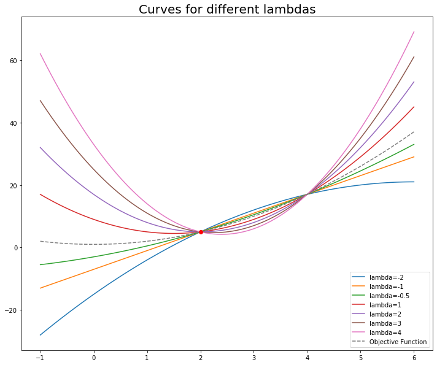

```python
import matplotlib.pyplot as plt
import numpy as np

def obective_function(x):
    return(x**2+1)

def lagrangian(x,lda):
    return((1+lda)*x**2-6*lda*x+(1+8*lda))

lambdas=[-2,-1,-0.5,1,2,3,4]
x = np.linspace(-1, 6, 100)

plt.figure(figsize=(12,10))
for l in lambdas:
    plt.plot(x, lagrangian(x, l), label ="lambda=" +str(l))
    plt.legend()
plt.plot(x, obective_function(x), label ='Objective Function', linestyle='dashed')

plt.plot(2,5,'ro')
plt.legend()
plt.title('Curves for different lambdas',size=20)
plt.show()
```

We can see that $p^*\geqslant \inf_x L$ only for $\lambda >-1 $.

Now find the derivative of $L$:

$$ L'(x^*)=2x+\lambda(x-2)+\lambda(x-4) $$

We get $$ x^*=\frac{3\lambda}{1+\lambda}$$

Thus, the Dual function:

$$ d(\lambda)=\left\{\begin{array}{ll} -9 \lambda^{2} /(1+\lambda)+1+8 \lambda & \lambda>-1 \\ -\infty & \lambda \leq-1 \end{array}\right. $$

### 3.

Lagrange dual problem: maximize $$d(\lambda)=-9\frac{\lambda^2}{1+\lambda}+8\lambda+1$$

subject to $$\lambda \geqslant 0$$

Dual optimum: $$\lambda=2, d^*=5$$

Strong duality holds

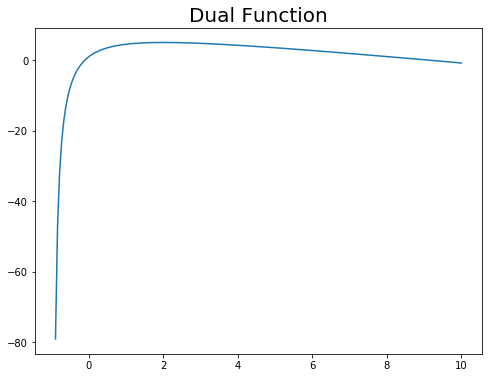

```python
def dual_function (x):
    return -9*x**2/(1+x)+1+8*x

xd=np.linspace(-0.9, 10, 200)

plt.figure(figsize=(8,6))
plt.plot(xd, dual_function(xd))
plt.title('Dual Function', size=20)
```

## Question 6:

### 1

Lagrangian: $$L=\frac{1}{2}x^TPx+\langle x,q\rangle+\lambda^T(Ax-b)=\frac{1}{2}x^TPx+q^Tx+\lambda^T(Ax-b)$$

$$L'=Px+q+\lambda^TA$$$$x^*=P^{-1}(A^T\lambda-q)$$

The dual function: $$d(\lambda)=\inf L(x^*,\lambda)=-\frac{1}{2}(A^T\lambda-q)^TP^{-1}(A^T\lambda-q)+b^T\lambda$$

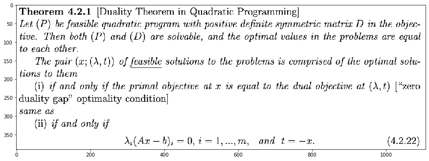

```python
img = plt.imread('./teorem.png',)
plt.figure(figsize=(15,8))
plt.imshow(img,interpolation='none')
```

### 2.

To use the theorem [source: https://ljk.imag.fr/membres/Anatoli.Iouditski/cours/convex/chapitre_4.pdf] let us introduce new veariable: $$t=-P^{-1}(A^T\lambda-q)$$

Then the dual problem is rewrited as: $$-\frac{1}{2}t^TPt+b^T\lambda \to \max | A^T\lambda+Pt=q, \lambda \geqslant 0$$

**In our case:** All the requirements of theorem are fulfiled: $P$ is symmetric positive definite, primal objective at x is equal to the dual objective at $(\lambda,t)$ So, both primal and dual problems are solvable and the pair $(x;(\lambda,t))$ of feasible solutions to the problem is comprised of optimal solutions to them.

.